# analysis

Load the libraries needed

```r
library(DESeq2)
library(tidyverse)
```

Read in the counts matrix using `read.table` and `as.matrix`

In the last lab, we manually generated a coldata. While convenient for small experiments, it would be better for us to directly create the coldata for the experiment based on the column names.

Use a combination of `colnames()`, `str_split_i()` and `data.frame()` to make the coldata. Name the column `condition`.

```
##        condition
## KO_840        KO
## KO_843        KO
## KO_857        KO
## KO_891        KO
## WT_841        WT
## WT_842        WT
## WT_858        WT
## WT_892        WT
```

**Now create a DESeq2 object as you’ve done in the past to test for DE using the design formula**

condition

Run DESeq2 and extract out the results comparing KO to WT

Convert the results to a tibble using `as_tibble()` and ensure you keep the rownames. Use a tidyverse function and report the number of genes that are significant with a padj < .15

```
## # A tibble: 141 × 7
##    gene_id               baseMean log2FoldChange lfcSE  stat   pvalue       padj
##    <chr>                    <dbl>          <dbl> <dbl> <dbl>    <dbl>      <dbl>
##  1 ENSMUSG00000104802.1     299.          -2.53  0.367 -6.88 6.16e-12    1.09e-7
##  2 ENSMUSG00000082536.1    2055.          -2.08  0.320 -6.51 7.63e-11    5.28e-7
##  3 ENSMUSG00000055027.17    329.          -2.20  0.339 -6.48 8.95e-11    5.28e-7
##  4 ENSMUSG00000027875.12   2073.          -2.92  0.472 -6.18 6.43e-10    2.84e-6
##  5 ENSMUSG00000004035.12    367.          -1.55  0.258 -6.01 1.82e- 9    5.38e-6
##  6 ENSMUSG00000060560.8      52.0          2.87  0.477  6.01 1.81e- 9    5.38e-6
##  7 ENSMUSG00000026452.15    238.           2.70  0.453  5.97 2.39e- 9    5.58e-6
##  8 ENSMUSG00000022803.12    737.          -1.04  0.174 -5.96 2.52e- 9    5.58e-6
##  9 ENSMUSG00000017639.13    579.          -1.81  0.309 -5.85 4.94e- 9    9.42e-6
## 10 ENSMUSG00000025420.13    317.          -0.864 0.148 -5.84 5.32e- 9    9.42e-6
## # ℹ 131 more rows
```

Technically, DESeq2 does not ever generate a normalized counts matrix. It performs normalization and the size factors are incorporated into the model. However, DESeq2 does provide a function to return a matrix of normalized counts. We are often interested in the normalized counts as visualizing them can help us confirm the success of our differential expression analysis as well as reveal other interesting patterns.

Find the appropriate function in DESeq2 and generate a matrix of normalized counts

Take the gene with the lowest padj and plot the normalized counts per sample. There are many ways to accomplish this.

I used a combination of `as_tibble()`, `filter`, `pivot_longer()`, `separate_wider_delim()`, `ggplot`, and `geom_col()`.

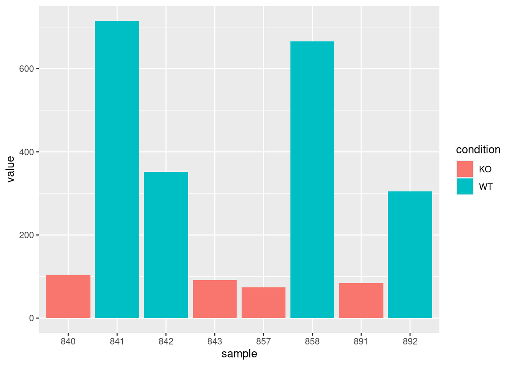

This was a gene called significantly differentially expressed, and you can see that in general, the counts are higher for the WT samples. However, there does appear to be large variance in the counts for the WT.

This was a real experiment and we noticed that we didn’t appear to have many differentially expressed genes in total but we observed a very striking phenotype. This led us to believe that we were missing something in our analysis.

If you look at the numbers of the samples, do you see any patterns?

As it turns out, this was an experiment done with mice and the numbers relay the information on which mice were part of which litter. 840, 841, 842, 842 were one litter of mice, 857 and 858 were another, and 891 and 892 another.

Oftentimes, there are other factors that we believe may be affecting gene expression. We call these covariates and it can be helpful to include them in your model when testing for differential expression.

Let’s redo the analysis and add in the knowledge of our samples.

Update your coldata by adding a new column indicating which litter samples came from. Assign the following labels by calling `data.frame` on coldata and adding a new column called litter. Remember you may make lists in R using `c()`, for example, c(‘L1’, ‘L1’) would make a list / vector of two elements.

```
##        condition litter
## KO_840        KO     L1
## KO_843        KO     L1
## KO_857        KO     L2
## KO_891        KO     L3
## WT_841        WT     L1
## WT_842        WT     L1
## WT_858        WT     L2
## WT_892        WT     L3
```

Let’s recreate our DESeq2 object with the new coldata and an updated design

```r
dds <- DESeqDataSetFromMatrix(countData=cts, colData=coldata, design= ~ litter + condition)
```

Re-run DESeq2 and regenerate the results

```r
dds <- DESeq(dds)
res <- results(dds, contrast=c("condition","KO","WT"))
resOrdered <- res[order(res$padj),]
```

Convert your results to a tibble and now report how many genes are significant at padj < .15.

```
## # A tibble: 774 × 7
##    gene_id               baseMean log2FoldChange lfcSE   stat   pvalue     padj
##    <chr>                    <dbl>          <dbl> <dbl>  <dbl>    <dbl>    <dbl>
##  1 ENSMUSG00000017639.13     579.          -1.78 0.174 -10.2  1.57e-24 2.37e-20
##  2 ENSMUSG00000055027.17     329.          -2.25 0.247  -9.14 6.33e-20 3.79e-16
##  3 ENSMUSG00000022912.8     3955.          -1.46 0.160  -9.12 7.53e-20 3.79e-16
##  4 ENSMUSG00000027875.12    2073.          -2.67 0.316  -8.46 2.77e-17 1.05e-13
##  5 ENSMUSG00000075254.11   10685.          -1.30 0.162  -7.99 1.34e-15 4.05e-12
##  6 ENSMUSG00000026043.18   43610.          -1.60 0.208  -7.69 1.44e-14 3.20e-11
##  7 ENSMUSG00000104802.1      299.          -2.48 0.323  -7.69 1.48e-14 3.20e-11
##  8 ENSMUSG00000032946.16     439.          -1.37 0.181  -7.59 3.30e-14 6.23e-11
##  9 ENSMUSG00000082536.1     2055.          -2.04 0.273  -7.47 8.04e-14 1.22e-10
## 10 ENSMUSG00000022037.14    4740.          -1.84 0.246  -7.48 7.58e-14 1.22e-10
## # ℹ 764 more rows
```

Re-extract the normalized counts

```r
new_norm_cts <- counts(dds, normalized=TRUE)
```

Now let’s plot the counts for the gene ENSMUSG00000025780.7:

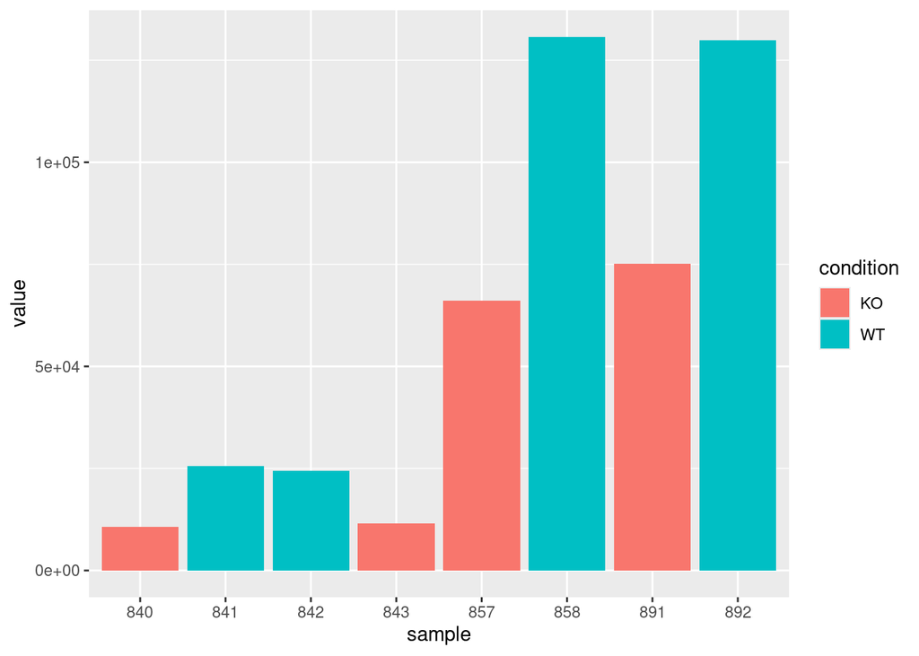

And the same for gene ENSMUSG00000002015.5

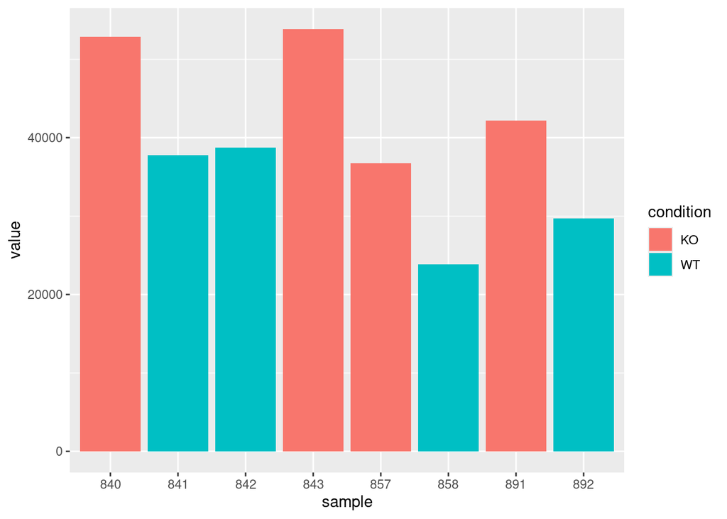